# Examples Explaining an Autonomous Agent’s Choices

erindb

```r
knitr::opts_chunk$set(echo=F, warning=F, message=F)
```

```
## [1] "installing webppl"
```

## Context

To sample counterfactually, we need to “pop free” of the actual state of the world.

But we want to preserve probabilistic causal relationships between variables, so we can’t pop *completely* free.

So we **infer** independent, exogenous random variables. All observables are deterministic functions of the states of those exogenous variables.

For a binary RV whose probability depends on an upstream variable, we can use a uniform RV as the independent, exogenous, latent variable.

## A problem

Generalizing from binary variables to categorical variables, it seems intuitive that we could use a uniform RV and the CDF to sample.

But this causes some undesirable asymmetries.

## Simulations

We have a variable u that’s sampled at uniform.

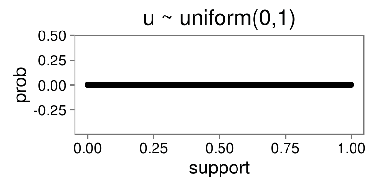

Given this variable u, we sample from 2 categorical distributions.

That is, we sample a value of u. Then we sample a value from a distribution deterministically using that value of u.

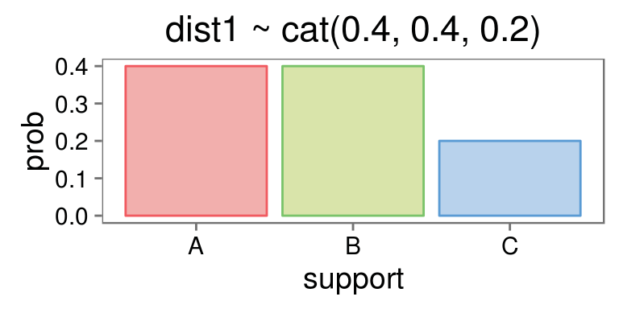

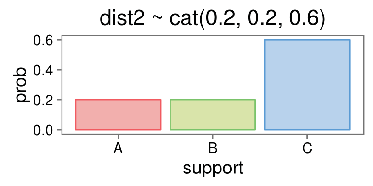

We can then sample from *the other* distribution using *the same value* of u. When we marginalize across all values of u and only look at the second sample, the marginal distributions are correct.

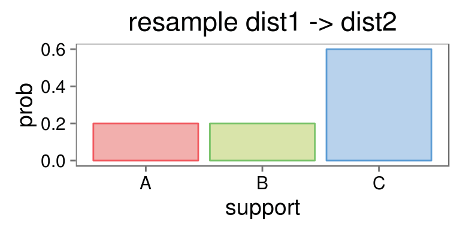

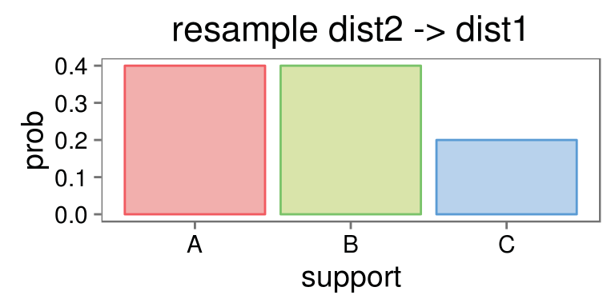

But if we record the *pairs* of samples, we see that this resampling process does not preserve probabilities in the way we would like.

It should be the case that the value is likely to stay the same across the two distributions. (The diagonal should have relatively high probability) and it should be the case that no cells have 0 probability (mayybe??? that’s not how the binary case works…).

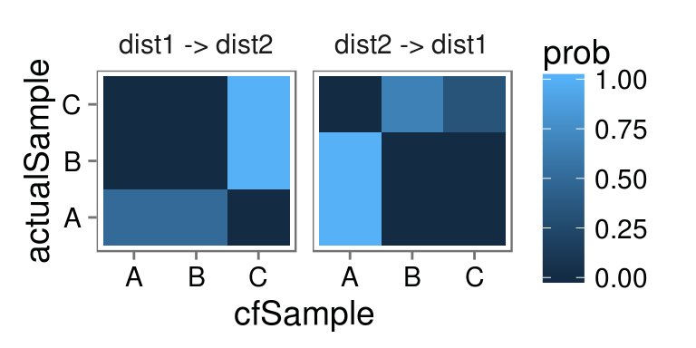

Rearranging the order or names of the support elments (“A”, “C”, “B”) can change this heatmap:

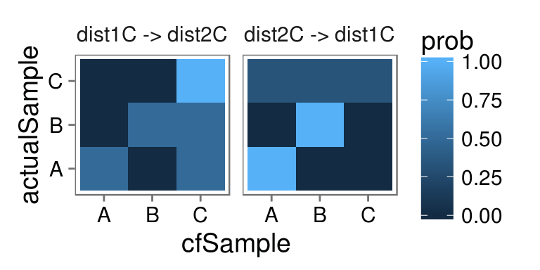

We can contrast this with similar distributions over binary variables.

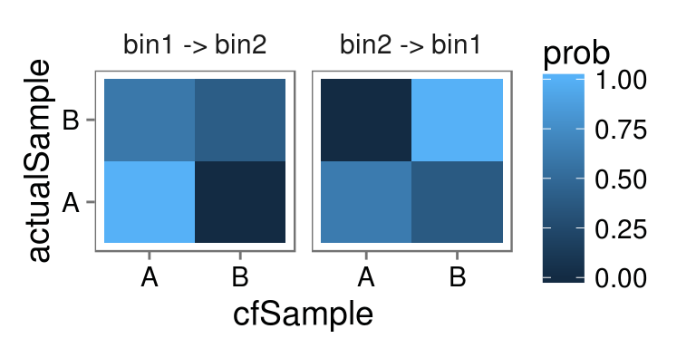

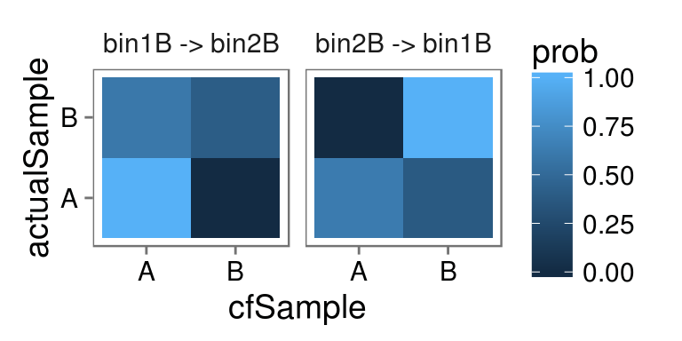

## Possible Solution

One extension of the CDF sampler that might be more well-behaved is one where maximal overlap is maintained betwen actual and countrfactual values.

The disadvantage of this is that some values with nonzero counterfactual probability cannot be reached from some actual values without the latent random variable being updated. But the binary case also has this property, so maybe it doesn’t matter. In fact, the more I think about this, the less I think it matters. Like, what if there were infinitely many unique values? Then it would be perfectly sensible for not every value to be reached from every other value.

Anyway, here are the results of that simulation.

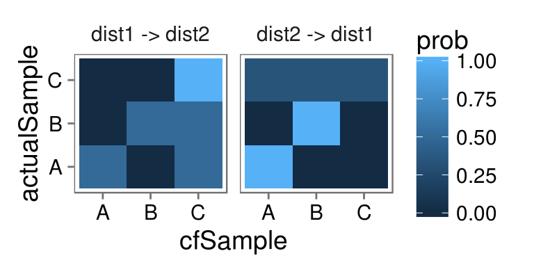

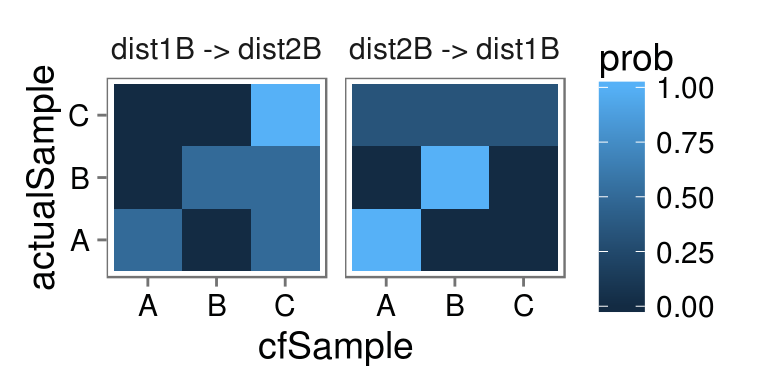

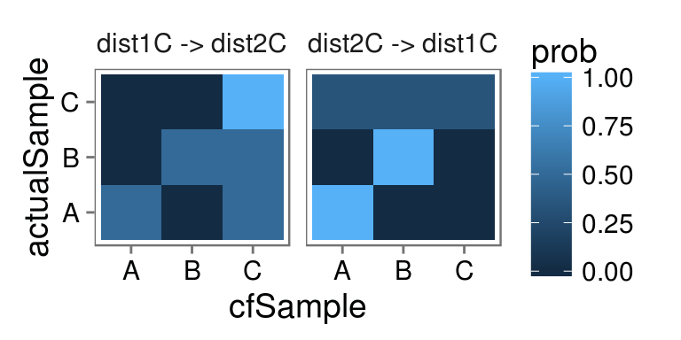

Note that order does not matter and that A and B (which have identical probabilities to each other in both distributions) have analogous counterfactual distributions.

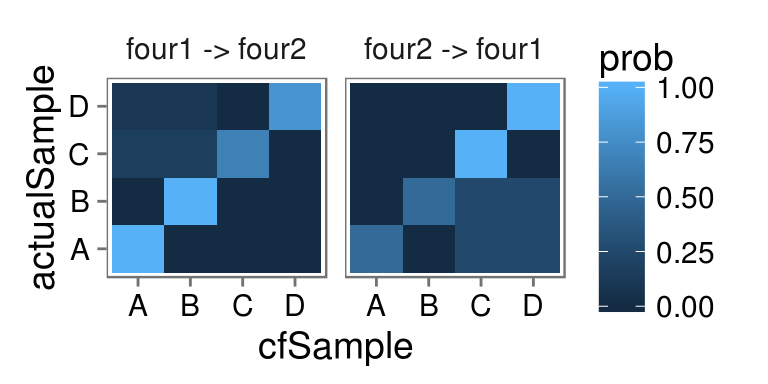

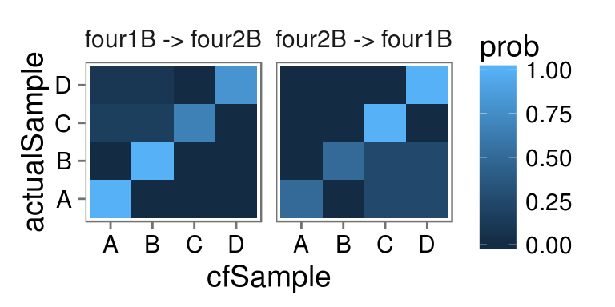

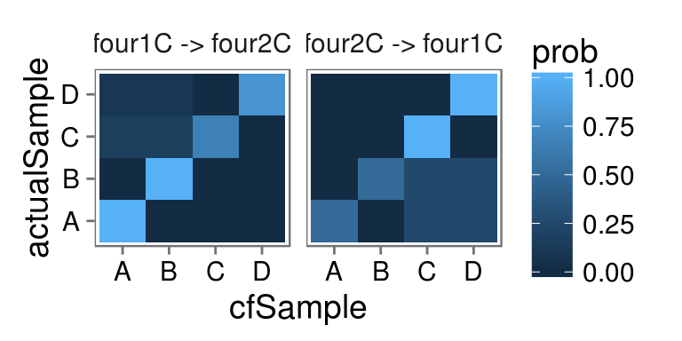

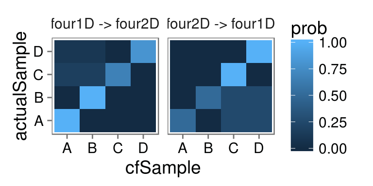

## How does this affect counterfactualizing?

How do the asymmetries we identified for the CDF sampler affect counterfactual sampling when we can pop free the latent uniform random variable?

Like, obviously a lot. I don’t really need to say more…

I mean, if sometimes the actual value doesn’t carry over at all, of course you’re going to run into weird counterfactual effects.